# Problem Set 12 Solutions

Jenny

2018-12-12

# Collaboration

Please indicate who you collaborated with on this problem set:

# Background

First load the necessary packages:

```r
library(tidyverse)
library(infer)
library(prettydoc)
```

For this Problem Set you will work with some grade-point-average (GPA) data for college freshman. The following will read in the data:

```r
sat_gpa <- read_csv("https://rudeboybert.github.io/SDS220/static/PS/sat_gpa.csv")
```

Use the `View()` function **in the console** to take a look at the data in the viewer. Each row or case in this data frame is a student. The data includes the (binary) gender of each student; the math, verbal and total SAT scores for each student; the GPA of each student in high school (categorized as “low” or “high”); and the GPA of each student their first year of college on a numeric scale.

We will use hypothesis testing to answer the following questions:

1. Is there a difference in male and female freshman GPAs?
2. Is there a difference in total SAT score for students with a “low” and “high” high-school GPA?

Note, if you get stuck as you are working through this, it will be helpful to go back and read Chapter 10 in ModernDive.

# Question 1: Gender differences in first-year GPA?

## Exploratory data analysis

#### Q1.a)

Calculate the mean GPA score for each gender, using the `group_by` and `summarize` commands from the `dplyr` package.

```r
avg_gpa_sex <- sat_gpa %>%
  group_by(sex) %>%
  summarize(gpa_fy = mean(gpa_fy))
avg_gpa_sex
```

| sex | gpa_fy |
| --- | --- |
| Female | 2.544587 |
| Male | 2.396066 |

**Questions**:

1. What is the difference in sample mean GPA’s?
2. Make a guess: is this difference statistically significant?

**Answers**:

1. Women had a higher sample mean GPA by 2.544587 - 2.396066 = 0.148521
2. Not sure?!?

#### Q1.b)

Generate a data visualization that displays the GPAs of the two groups. Be sure to include a title and label your axes.

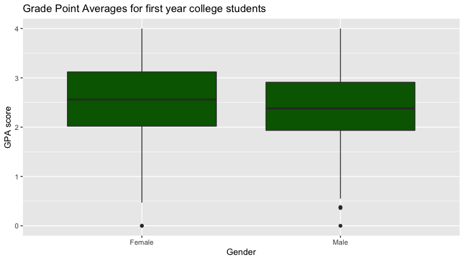

```r
ggplot(sat_gpa, aes(x = sex, y = gpa_fy)) +
  geom_boxplot(fill = "darkgreen") +
  labs(title = "Grade Point Averages for first year college students",
       x = "Gender", y = "GPA score")
```

## Stating a null hypothesis

We will now test the null hypothesis that there’s no difference in population mean GPA between the genders at the population level. We can write this out in mathematical notation

$$\begin{aligned} H_0:&\mu_{male} = \mu_{female} \\\ \mbox{vs }H_A:& \mu_{male} \neq \mu_{female} \end{aligned}$$

or expressed differently, that the difference is 0 or not:

$$\begin{aligned} H_0:&\mu_{male} - \mu_{female} = 0 \\\ \mbox{vs }H_A:& \mu_{male} - \mu_{female} \neq 0 \end{aligned}$$

## Testing the hypothesis

Here’s how we use infer to run this hypothesis test:

### Step 1: Calculate the observed difference

Note that the order we choose does not matter here (female them male)…but since we used `order = c("Female", "Male")` here, we should do the same in subsequent calculations!

```r
obs_diff_gpa_sex <- sat_gpa %>%
  specify(gpa_fy ~ sex) %>%
  calculate(stat = "diff in means", order = c("Female", "Male"))

obs_diff_gpa_sex
```

| stat |
| --- |
| 0.1485209 |

Note that this is the difference in the group means we calculated earlier!

```r
2.544587 - 2.396066
```

```
## [1] 0.148521
```

### Step 2. Generate the null distribution of $\delta$

This step involves generating simulated values *as if* we lived in a world where there’s no difference between the two groups. Going back to the idea of permutation, and tactile sampling, this is akin to shuffling the GPA scores between male and female labels (i.e. removing the structure to the data) just as we could have done with index cards.

```r
gpas_in_null_world <- sat_gpa %>%
  specify(gpa_fy ~ sex) %>%
  hypothesize(null = "independence") %>%
  generate(reps = 5000)
```

#### Q1.c)

**Question**:

1. What was the size of the “shuffled” (permuted) sample in each run?
2. How many times did we do a different “shuffle” (permute) here to the sample? How many rows are in the `gpas_in_null_world` data frame?

**Answer:**

1. The sample size is 1000, the size of the original sample.
2. The sample was permuted 5000 times. 1000 * 5000 = 5 million

### Step 3. Calculate the differences between male and females under the null

The following calculates the differences in mean GPA for males and females for “shuffled” (permuted) data.

```r
gpa_diff_under_null <- gpas_in_null_world %>%
  calculate(stat = "diff in means", order = c("Female", "Male"))

gpa_diff_under_null %>%
  slice(1:5)
```

| replicate | stat |
| --- | --- |
| 1 | -0.0272992 |
| 2 | -0.0598124 |
| 3 | 0.0167860 |
| 4 | 0.0160653 |
| 5 | -0.0079994 |

#### Q1.d)

**Question**:

1. How many rows are in this data frame? Why?

**Answer:**

5000. There is one for each replicate in which we shuffled.

### Step 4. Visualize how the observed difference compares to the null distribution of $\delta$

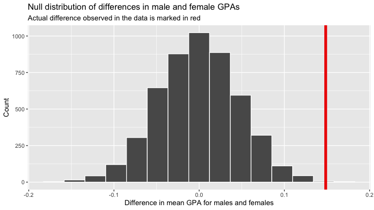

```r
gpa_diff_under_null %>%
  visualize(obs_stat = obs_diff_gpa_sex) +
  labs(x = "Difference in mean GPA for males and females", y = "Count",
       title = "Null distribution of differences in male and female GPAs",
      subtitle = "Actual difference observed in the data is marked in red")
```

**Note that zero is the center of this null distribution.** The null hypothesis is that there is no difference between males and females in GPA score. In the permutations, zero was the most common value, because all structure was removed from the data…GPA values were sorted into male and female **at random**. Values as large as ~ 0.1 and -0.1 occurred, but much less frequently, because they are just not as likely when structure is removed from the data.

### Step 5: Calculate a p-value

```r
gpa_diff_under_null %>%
  get_pvalue(obs_stat = obs_diff_gpa_sex, direction = "both")
```

| p_value |
| --- |
| 0.0026 |

### Step 6: Calculate a confidence interval for the difference

The following will allow us to calculate a 95% confidence interval for the difference between mean GPA scores for males and females.

```r
ci_diff_gpa_means <- sat_gpa %>%
  specify(gpa_fy ~ sex) %>%
  generate(reps = 5000) %>%
  calculate(stat = "diff in means", order = c("Female", "Male")) %>%
  get_ci(level = 0.95)
ci_diff_gpa_means
```

| 2.5% | 97.5% |
| --- | --- |
| 0.0559788 | 0.2400259 |

## Complete all the above tasks with a t-test

Note that all the above steps can be done with one line of code **if a slew of assumptions** like normality and equal variance of the groups are met.

```r
t.test(gpa_fy ~ sex, var.equal = TRUE, data = sat_gpa)
```

```
##
##  Two Sample t-test
##
## data:  gpa_fy by sex
## t = 3.1828, df = 998, p-value = 0.001504
## alternative hypothesis: true difference in means is not equal to 0
## 95 percent confidence interval:
##  0.05695029 0.24009148
## sample estimates:
## mean in group Female   mean in group Male
##             2.544587             2.396066
```

# Question 2: Relationship between high-school & first-year GPA?

For this analysis `sat_total` is the outcome variable, and `gpa_hs` is the predictor variable, with two levels “low” and “high”.

## Exploratory data analysis

We can first calculate the mean total SAT score for each group (i.e students with a low and high GPA), using the `group_by` and `summarize` commands from the `dplyr` package.

```r
avg_sat_gpa <- sat_gpa %>%
  group_by(gpa_hs) %>%
  summarize(sat_total = mean(sat_total))

avg_sat_gpa
```

| gpa_hs | sat_total |
| --- | --- |
| high | 108.67828 |
| low | 98.23047 |

We will next generate a data visualization that displays the total SAT scores of the two groups. Be sure to include a title and label your axes.

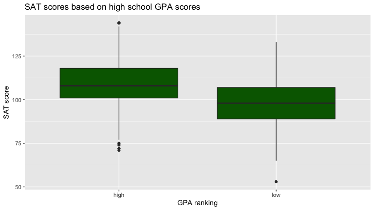

```r
ggplot(sat_gpa, aes(x = gpa_hs, y = sat_total)) +
  geom_boxplot(fill = "darkgreen") +
  labs(title = "SAT scores based on high school GPA scores",
       x = "GPA ranking", y = "SAT score")
```

## Stating a null hypothesis

#### Q2.a)

**Question:** State the null hypothesis that you are testing.

**Answer:** There is no difference in mean SAT scores between students with low high-school GPA scores and those with high GPA scores **at the population level** or with symbols.

$$\begin{aligned} H_0:& \mu_{\text{low hs gpa}} = \mu_{\text{high hs gpa}} \\\ \mbox{vs }H_A:& \mu_{\text{low hs gpa}} \neq \mu_{\text{high hs gpa}} \end{aligned}$$

or expressed differently, that the difference is 0 or not:

$$\begin{aligned} H_0:& \mu_{\text{low hs gpa}} - \mu_{\text{high hs gpa}} = 0 \\\ \mbox{vs }H_A:& \mu_{\text{low hs gpa}} - \mu_{\text{high hs gpa}} \neq 0 \end{aligned}$$

## Testing the hypothesis

#### Q2.b)

Calculate the observed difference between the mean total SAT scores of the low and high GPA high-school students.

```r
obs_diff_sat_hs_gpa <- sat_gpa %>%
  specify(sat_total ~ gpa_hs) %>%
  calculate(stat = "diff in means", order = c("high", "low"))

obs_diff_sat_hs_gpa
```

| stat |
| --- |
| 10.44781 |

```r
# # note to grader...the following are also OK or
# obs_diff_sat_hs_gpa <- sat_gpa %>%
#   specify(sat_total ~ gpa_hs) %>%
#   calculate(stat = "diff in means", order = c("low", "high"))
# # or
# obs_diff_sat_hs_gpa <- 98.23047 - 108.67828
# # or
# obs_diff_sat_hs_gpa <- 108.67828 - 98.23047
```

#### Q2.c)

Generate the null distribution of $\delta$. Here you need to generate simulated values *as if* we lived in a world where there’s no difference in SAT scores between high school students with low and high GPAs.

```r
sat_in_null_world <- sat_gpa %>%
  specify(sat_total ~ gpa_hs) %>%
  hypothesize(null = "independence") %>%
  generate(reps = 5000)
```

#### Q2.d)

Calculate the differences in mean SAT scores between students with low and high GPA scores under the Null. Note…you should use whatever order you chose above…i.e. `order = c("low", "high")` or `order = c("high", "low")`.

```r
sat_diff_under_null <- sat_in_null_world %>%
  calculate(stat = "diff in means", order = c("high", "low"))

sat_diff_under_null %>%
  slice(1:5)
```

| replicate | stat |
| --- | --- |
| 1 | 1.6547451 |
| 2 | -0.5625320 |
| 3 | -0.7426358 |
| 4 | 0.1899014 |
| 5 | -0.1623015 |

#### Q2.e)

Visualize how the observed difference compares to the null distribution of $\delta$. Generate a histogram of the null distribution, with a vertical red line showing the observed difference in SAT scores between high school students with a high and low GPA.

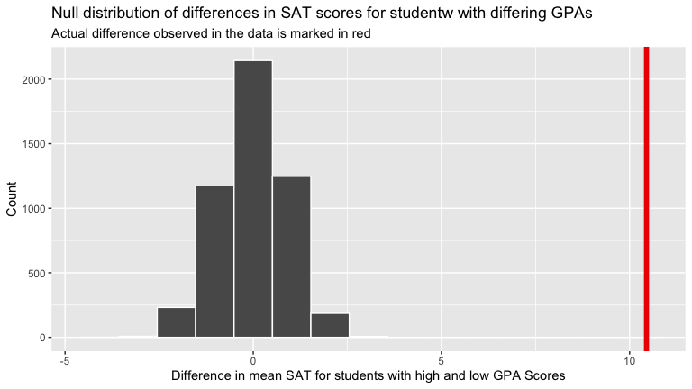

```r
sat_diff_under_null %>%
  visualize(obs_stat = obs_diff_sat_hs_gpa ) +
  labs(x = "Difference in mean SAT for students with high and low GPA Scores", y = "Count",
       title = "Null distribution of differences in SAT scores for studentw with differing GPAs",
      subtitle = "Actual difference observed in the data is marked in red")
```

#### Q2.f)

Calculate a p-value

```r
sat_diff_under_null %>%
  get_pvalue(obs_stat = obs_diff_sat_hs_gpa, direction = "both") %>%
 signif(digits = 22)
```

| p_value |
| --- |
| 0 |

#### Q2.g)

Write up the results & conclusions for this hypothesis test. Note, p-values less than 0.001 are often reported as p < 0.001.

**Answer:** The mean SAT score for students with a low high school GPA in our sample ($\bar{x}$ = **98**) was lower than that of students with a high high school GPA ($\bar{x}$ = **108**). This difference **was** statistically significant at $\alpha = 0.05$, (p < **0.001**). Given this I **would** reject the Null hypothesis and conclude that **students with higher high school GPA scores** have higher SAT scores than **students with lower high school GPA scores** at the population level.

#### Q2.h)

Calculate a confidence interval for the difference in total SAT scores for students with high and low high-school GPA scores. Note…you should use whatever order you chose above…i.e. `order = c("low", "high")` or `order = c("high", "low")`.

```r
ci_diff_sat_means <- sat_gpa %>%
  specify(sat_total ~ gpa_hs) %>%
  generate(reps = 5000) %>%
  calculate(stat = "diff in means", order = c("high", "low")) %>%
  get_ci(level = 0.95)
ci_diff_sat_means
```

| 2.5% | 97.5% |
| --- | --- |
| 8.766145 | 12.06833 |

#### Q2.i)

Use a t-test to test the null hypothesis that total SAT scores do not differ between students with high and low high school GPA scores at the population level.

```r
t.test(sat_total ~ gpa_hs, var.equal = TRUE, data = sat_gpa)
```

```
##
##  Two Sample t-test
##
## data:  sat_total by gpa_hs
## t = 12.413, df = 998, p-value < 2.2e-16
## alternative hypothesis: true difference in means is not equal to 0
## 95 percent confidence interval:
##   8.79614 12.09948
## sample estimates:
## mean in group high  mean in group low
##          108.67828           98.23047
```